# Chi-square Test

Jesse

2019年11月18日

# Chi-Square Test.

Today we learn how to do chi-square test toward data.

You may download *Smoking* data from https://www.openintro.org/stat/data.php?data=smoking.  
It surveys the smoking habit in UK.

Some important variables explained in the following:

- gender : Gender with levels Female and Male.
- nationality : Nationality with levels British, English, Irish, Scottish, Welsh, Other, Refused and Unknown.
- marital_status : Marital status with levels Divorced, Married, Separated, Single and Widowed.
- smoke : Smoking status with levels No and Yes

Today, we gonna test if the above three variables have association with the smoking habit.

## Read data.

As usual, we use `read.csv` to read csv files.

```r
smoking <- read.csv("C:/Users/asus/Desktop/TA/TA session/week10/smoking.csv")
```

## Basic data analysis.

We wanna to know more about the relation between smoke and *gender, nationality, marital_status* respectively. Here, we produce *a contingency table of percentage* and *do some plots*.

Firstly, we conduct plots to see the distribution of smoke or not filter by the *gender, nationality, marital_status*.  
Here, we found that *barplot* would help a lot.

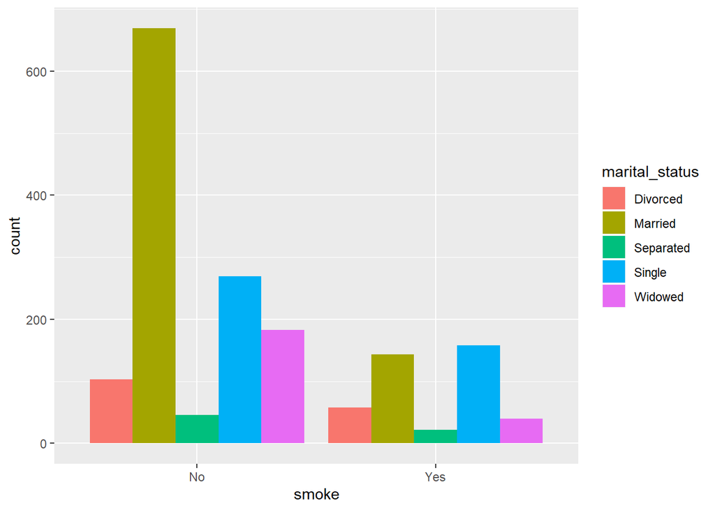

```r
ggplot(data = smoking) +
  geom_bar(mapping = aes(x=smoke, fill=marital_status), position = "dodge")
```

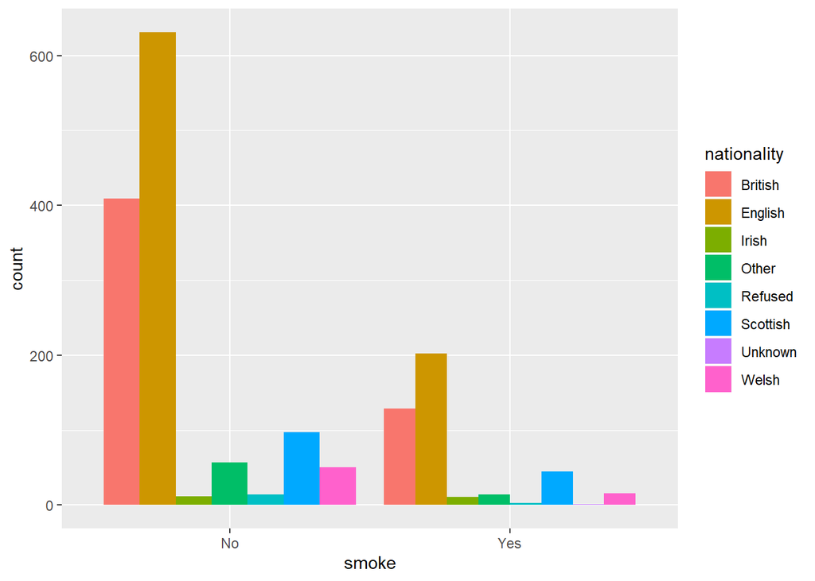

```r
ggplot(data = smoking) +
  geom_bar(mapping = aes(x=smoke, fill=nationality), position = "dodge")
```

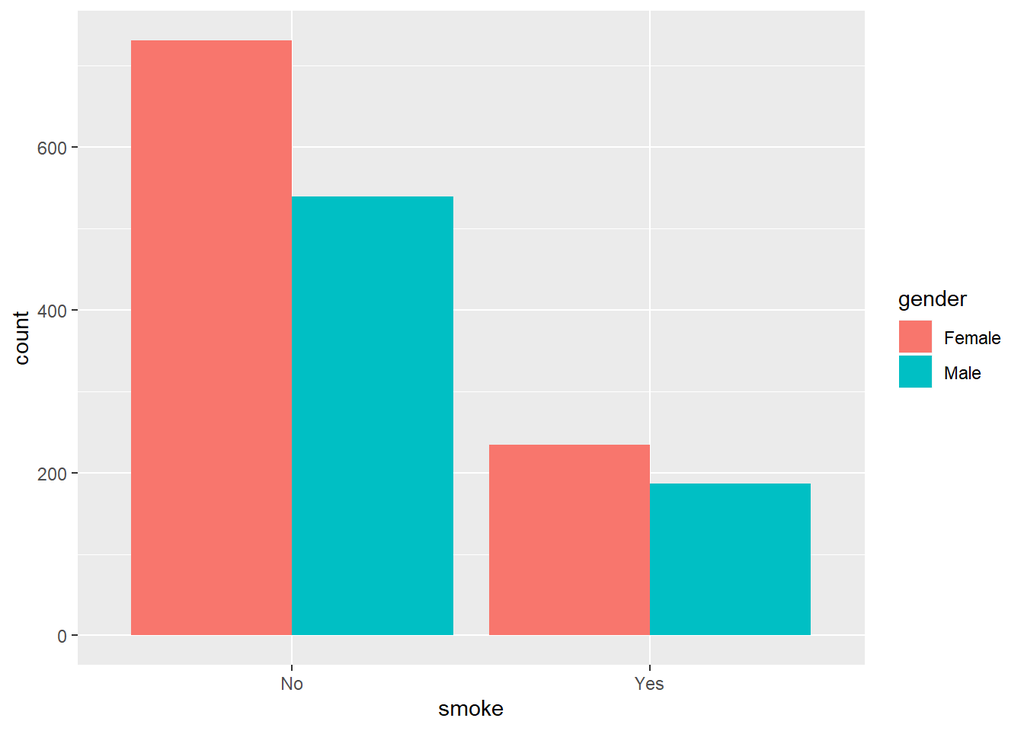

```r
ggplot(data = smoking) +
  geom_bar(mapping = aes(x=smoke, fill=gender), position = "dodge")
```

Secondly. we try conducting contingency table of percentage to furthur see the distribution by percentage.

```r
gender.smoke <- table(smoking$smoke, smoking$gender)
gender.smoke.pro <- prop.table(gender.smoke, margin = 2)
print(gender.smoke.pro)
```

```
##
##          Female      Male
##   No  0.7575130 0.7424242
##   Yes 0.2424870 0.2575758
```

```r
marital.smoke <- table(smoking$smoke, smoking$marital_status)
marital.smoke.pro <- prop.table(marital.smoke, margin = 2)
print(marital.smoke.pro)
```

```
##
##        Divorced   Married Separated    Single   Widowed
##   No  0.6397516 0.8238916 0.6764706 0.6299766 0.8206278
##   Yes 0.3602484 0.1761084 0.3235294 0.3700234 0.1793722
```

```r
nationality.smoke <- table(smoking$smoke, smoking$nationality)
nationality.smoke.pro <- prop.table(nationality.smoke, margin = 2)
print(nationality.smoke.pro)
```

```
##
##         British   English     Irish     Other   Refused  Scottish
##   No  0.7602230 0.7575030 0.5217391 0.8028169 0.8235294 0.6830986
##   Yes 0.2397770 0.2424970 0.4782609 0.1971831 0.1764706 0.3169014
##
##         Unknown     Welsh
##   No  0.0000000 0.7575758
##   Yes 1.0000000 0.2424242
```

## Conduct chi-square test.

Finally, we conduct chi-square test to see if the three variables have association with smoke.

```r
chisq.test(gender.smoke)
```

```
##
##  Pearson's Chi-squared test with Yates' continuity correction
##
## data:  gender.smoke
## X-squared = 0.42699, df = 1, p-value = 0.5135
```

```r
chisq.test(marital.smoke)
```

```
##
##  Pearson's Chi-squared test
##
## data:  marital.smoke
## X-squared = 74.98, df = 4, p-value = 2.012e-15
```

```r
chisq.test(nationality.smoke)
```

```
##
##  Pearson's Chi-squared test
##
## data:  nationality.smoke
## X-squared = 14.929, df = 7, p-value = 0.03692
```

if we set a = 0.05 We can see **marital_status. nationality** both have association with smoking habit.

### Question

You may donwload *absenteeism* dataset from https://www.openintro.org/stat/data.php?data=absenteeism .  
Reserachers collected data from 146 randomly sampled students in rural New South Wales, Australia, in a particular school year.

Some important variables explained in the following:

- sex : Gender.
- lrn : Learner status, with average learner (`AL`) and slow learner (`SL`).

We wanna test if there’s strong association between gender and learning status. a = 0.05.

1. Make a two-way by-percentage contingency table of the sex and lrn.
2. Do some plots to know more about them.
3. Do chi-suare test.